# Subreddit-Analysis

mutbi

4/25/2020

I love Reddit. I open it almost every day, every night. I honestly open it to see memes most of the time, but other than memes, you can find many other subreddits that aligned with your interest or hobbies. One of the subreddit that I subscribed to is r/dataisbeautiful. It is a subreddit to share data visualitations and many of them are interesting. I never post anything on this sub though, I’m just a lurker.

So, today I have a dataset that contains 173,611 unique posts that have been posted in r/dataisbeautiful. I got this data from this link (https://www.kaggle.com/unanimad/dataisbeautiful). And I’m interested to find out what kind of insight this dataset could offer, if any.

To start off, let’s import the dataset to our R environment.

```r
reddit = read.csv('r_dataisbeautiful_posts.csv', header=T, sep=',')
```

Next, I will do data checking. Data checking process that I usually do is to check dataset summary, dataset’s first 5 lines, checking null values, and checking outliers.

```r
library(dplyr)
# - Quick Summary - #
summary(reddit)
```

```
##        id
##  1003l3 :     1
##  1009e9 :     1
##  100h4g :     1
##  100nxj :     1
##  1016iy :     1
##  1019ej :     1
##  (Other):173605
##                                                                                    title
##  data_irl                                                                             :  1060
##  Data_irl                                                                             :   360
##  裕美･ルミィヤンツェヴァのスライドショー                                              :   320
##  Title your visualization but keep the closing tag [OC]                               :   117
##  Dataviz Open Discussion Thread for /r/dataisbeautiful                                :   103
##  GitHub - gabrielbull/react-aim: Determine the cursor aim for triggering mouse events.:    60
##  (Other)                                                                              :171591
##      score                 author              author_flair_text
##  Min.   :     0.0   [deleted] : 27400                   :151582
##  1st Qu.:     1.0   jimrosenz :  2258   OC: 1           :  7281
##  Median :     1.0   OverflowDs:   477   OC: 2           :  2640
##  Mean   :   193.9   RAGTIMEMA :   325   Viz Practitioner:  2030
##  3rd Qu.:     5.0   rhiever   :   321   OC: 3           :  1444
##  Max.   :116226.0   caobanlong:   314   OC: 4           :   928
##                     (Other)   :142516   (Other)         :  7706
##             removed_by     total_awards_received
##                  :167068   Min.   :0
##  author          :     1   1st Qu.:0
##  automod_filtered:   752   Median :0
##  deleted         :   574   Mean   :0
##  moderator       :  4556   3rd Qu.:0
##  reddit          :   660   Max.   :8
##                            NA's   :140006
##                 awarders       created_utc
##                     :150681   Min.   :1.329e+09
##  ['stompstumpstamp']:     1   1st Qu.:1.445e+09
##  []                 : 22929   Median :1.491e+09
##                               Mean   :1.492e+09
##                               3rd Qu.:1.546e+09
##                               Max.   :1.587e+09
##
##                                                                                                       full_link
##  https://www.reddit.com/r/dataisbeautiful/comments/1003l3/economic_growth_versus_tax_cuts_and_increases_so/:     1
##  https://www.reddit.com/r/dataisbeautiful/comments/1009e9/improvement_sex_and_care_health/                 :     1
##  https://www.reddit.com/r/dataisbeautiful/comments/100h4g/ncaa_football_coach_salary_vs_winning_percentage/:     1
##  https://www.reddit.com/r/dataisbeautiful/comments/100nxj/men_how_to_make_an_impression_on_russian_women/  :     1
##  https://www.reddit.com/r/dataisbeautiful/comments/1016iy/a_visualization_obamas_v_romneys_speeches_xpost/ :     1
##  https://www.reddit.com/r/dataisbeautiful/comments/1019ej/visualizing_a_7_set_venn_diagram/                :     1
##  (Other)                                                                                                   :173605
##   num_comments       over_18
##  Min.   :    0.00   False:172720
##  1st Qu.:    1.00   True :   891
##  Median :    1.00
##  Mean   :   25.28
##  3rd Qu.:    4.00
##  Max.   :18801.00
##
```

What I’ve noticed from this summary are: 1. The IDs are unique, but the titles are not. There are some titles that appear multiple times, like “data_irl” appears 1060 times, “Data_irl” appears 360 times, etc. So, I think those posts are not an Original Content [OC], probably they are some general posts that are posted by the subreddit’s mod (like this: “Dataviz Open Discussion Thread for /r/dataisbeautiful”) or they are sharable contents from Github (like “GitHub - gabrielbull/react-aim:”). Because of this, I will check the data distribution from title frequency, finding the outlier and probably delete the outliers.

2. total_awards_received column is mostly Null, so I’m not going to use that.
3. Same with awarders column, I’m not going to use it either.
4. Created_utc is still in integer format, I will change it to date time format.

Move on…

```r
#Check First 5 Rows
head(reddit)
```

```
##       id
## 1 g0l1o6
## 2 g0kxzc
## 3 g0kwbp
## 4 g0ktji
## 5 g0kiyr
## 6 g0kipf
##                                                                                                                                                                                    title
## 1                                                                                                [OC] Website about covid-19 pandemic stats with several data visualizations/Graph types
## 2                                                                                                                              Dynamic timeline of the founding of major European cities
## 3 Despite more than four weeks to complete it, I crammed writing the report into the five hours before the deadline...and my word count over time makes a near perfect linear trend [OC]
## 4                                                                                            [OC] Reported Coronavirus Tests per million as of April 13, 2020 (14:00 UTC/10:00 A.M. EDT)
## 5                                                                                                                                                [OC] House M.D.-IMDB rating of episodes
## 6                                                                                                              The Spread of Coronavirus in Italy (First Case to April 11) 2020 (UPDATE)
##   score        author author_flair_text removed_by total_awards_received
```

[output cut: 27 more lines]

```r
#Change created_utc to datetime format
reddit$created_utc = as.POSIXct.numeric(reddit$created_utc, origin = '1970-01-01 00:00:00')

# Finding outliers
duplicate_titles = reddit %>%
  group_by(title)%>%
  summarize(
    count=n()
  )

table(as.factor(duplicate_titles$count)) ## 88% of titles have 1 count
```

```
##
##      1      2      3      4      5      6      7      8      9     10
## 153266   6138    887    241     82     43     38     14      7      8
##     11     12     13     14     15     16     17     18     19     20
##      5      2      4      6      2      1      4      2      4      2
##     22     23     24     25     27     29     30     33     35     36
##      3      3      3      2      1      2      1      1      1      1
##     39     40     45     56     59     60    103    117    320    360
##      2      1      1      1      1      1      1      1      1      1
##   1060
##      1
```

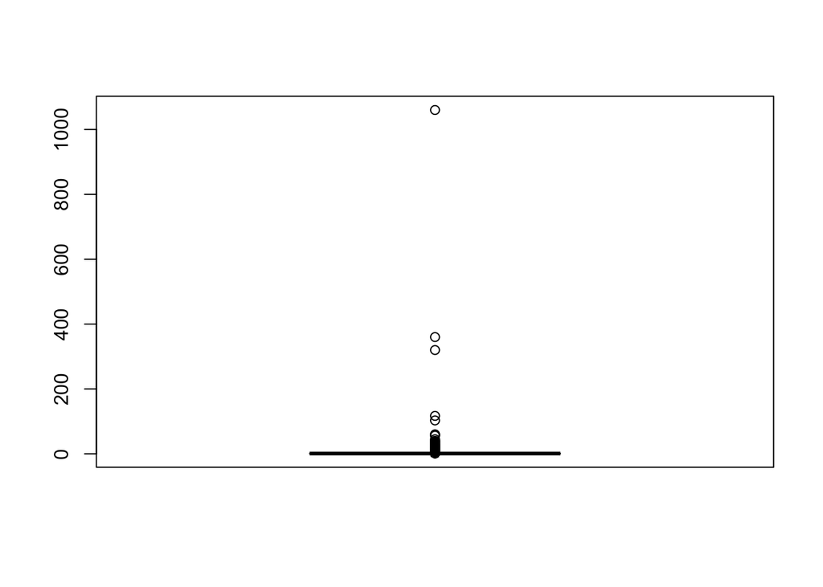

```r
#checking data Distribution for titles's frequency
boxplot(duplicate_titles$count)
```

```r
min(boxplot.stats(duplicate_titles$count)$out) ## titles that have count >=2 are outliers
```

```
## [1] 2
```

```r
non_duplicate_titles = duplicate_titles$title[which(duplicate_titles$count==1)] # filter the titles that are not duplicates

clean_reddit = reddit[which(reddit$title %in% non_duplicate_titles),] # clean dataset to only contains titles that have no duplicates

summary(clean_reddit)
```

```
##        id
##  1003l3 :     1
##  1009e9 :     1
##  100h4g :     1
##  100nxj :     1
##  1016iy :     1
##  1019ej :     1
##  (Other):153260
##                                                              title
##  \nBeer brands most "liked" on Facebook by U.S. college students\n:     1
##   A Github for Datasets - what do you guys think?                 :     1
##   Global migrants: Which are the most wanted professions?         :     1
##   I think you guys are right.                                     :     1
##   Tech patent lawsuits in the past four years.                    :     1
##   The average age of Reidditors is 34 and 65% are males.          :     1
##  (Other)                                                          :153260
##      score                 author              author_flair_text
##  Min.   :     0.0   [deleted] : 22487                   :133446
##  1st Qu.:     1.0   jimrosenz :  2039   OC: 1           :  6637
##  Median :     1.0   OverflowDs:   425   OC: 2           :  2392
##  Mean   :   175.3   caobanlong:   310   Viz Practitioner:  1903
##  3rd Qu.:     5.0   sofl96    :   310   OC: 3           :  1288
##  Max.   :116226.0   rhiever   :   269   OC: 4           :   849
##                     (Other)   :127426   (Other)         :  6751
##             removed_by     total_awards_received
##                  :147644   Min.   :0
##  author          :     0   1st Qu.:0
##  automod_filtered:   604   Median :0
##  deleted         :   473   Mean   :0
##  moderator       :  3995   3rd Qu.:0
##  reddit          :   550   Max.   :8
##                            NA's   :123823
##                 awarders       created_utc
##                     :132999   Min.   :2012-02-15 06:50:56
##  ['stompstumpstamp']:     1   1st Qu.:2015-09-29 04:07:04
##  []                 : 20266   Median :2017-03-27 03:10:56
##                               Mean   :2017-03-25 00:17:05
##                               3rd Qu.:2018-12-10 21:44:59
##                               Max.   :2020-04-13 22:25:06
##
##                                                                                                       full_link
##  https://www.reddit.com/r/dataisbeautiful/comments/1003l3/economic_growth_versus_tax_cuts_and_increases_so/:     1
##  https://www.reddit.com/r/dataisbeautiful/comments/1009e9/improvement_sex_and_care_health/                 :     1
##  https://www.reddit.com/r/dataisbeautiful/comments/100h4g/ncaa_football_coach_salary_vs_winning_percentage/:     1
##  https://www.reddit.com/r/dataisbeautiful/comments/100nxj/men_how_to_make_an_impression_on_russian_women/  :     1
##  https://www.reddit.com/r/dataisbeautiful/comments/1016iy/a_visualization_obamas_v_romneys_speeches_xpost/ :     1
##  https://www.reddit.com/r/dataisbeautiful/comments/1019ej/visualizing_a_7_set_venn_diagram/                :     1
##  (Other)                                                                                                   :153260
##   num_comments       over_18
##  Min.   :    0.00   False:152472
##  1st Qu.:    1.00   True :   794
##  Median :    1.00
##  Mean   :   23.59
##  3rd Qu.:    4.00
##  Max.   :10425.00
##
```

Okay. We’ve checked the summary, found the column with null values, saw the first 5 rows in the dataset, and removed the outliers.

Before I move to Data Cleaning process, I usually start to list down the questions that I want to find out after saw what’s inside of this data. So, here is the question I want to anwer: “Can we see a trending topic/subject from title from 2012 until 2020?”.

So, I will do two words extraction from the title. I know I will do tacky data cleaning to remove words that are not relevant, so bear with me ;)

```r
#### Extract Two Words ####
# loading library
library(tidytext)
library(tidyr)
library(tm)
library(data.table)
library(stringr)
library(lubridate)
library(stopwords)
library(zoo)
# any sentence are full of stop words like ('a','of','the',etc), so I need to remove them because they're noises
# loading stop words
stop_words = data.frame(word=as.character(stopwords(language = 'en')))

#change title's data type from factor to string
clean_reddit$title = as.character(clean_reddit$title)

# extract two words from title
twowords = clean_reddit%>%
  unnest_tokens(word,title, token = "ngrams", n = 2)

# separate bigrams with space to filter out stop words easier
twowords <- twowords %>%
  separate(word, c("word1", "word2"), sep = " ")

# filter our stopwords
twowords <- twowords %>%
  filter(!word1 %in% stop_words$word & !word2 %in% stop_words$word)

#remove 'oc' (tag for original content)
twowords = twowords[which(twowords$word1 != 'oc' & twowords$word2 != 'oc' ),]

# add new column to extract month and year from created_utc
twowords$month = format(as.Date(twowords$created_utc), "%Y-%m")

#change month data type from char to yearmonth
twowords$month = as.yearmon(twowords$month)

# add new column to extract year from created_utc
twowords$year = year(twowords$created_utc)

# combine word1 and word2 back
twowords$words = paste(twowords$word1,twowords$word2)
twowords$word1 = NULL
twowords$word2 = NULL

# count frequency of words and filter stop words
twowords_freq <- twowords %>%
  group_by(month ,words)%>%
  summarize(
    freq = n()
  )

# see the first 5 rows
head(twowords)
```

[output not shown]

After looking into twowords_freq, I see that many top mentioned words are like ‘top 10’, ‘top 15’, ‘top 20’, etc. Because it doesn’t tell me anything, I will remove these type of words.

```r
twowords_freq = twowords_freq%>%
  filter(!words %like% c('top'))
```

Before moving to data visualisation, I think the chart/plot will look messy if I put all words into the chart. Hence, I want to keep it simple by only showing the number 1 trending words per month.

Below is the code to add rank column and show data visualisation. I’m getting lazier as this post getting longer, so I will write everything in the comments.

```r
# add new column as rank
twowords_freq <- twowords_freq %>%
  group_by(month)%>%
  arrange(desc(freq))%>%
  mutate(
    rank = row_number()
  )

# data visualisation
library(ggplot2)
library(plotly)
plot = twowords_freq%>%
  filter(rank == 1)%>%
  ggplot(aes(x=month, y=freq, color=words))+
  geom_segment( aes(x=month, xend=month, y=0, yend=freq), color="grey", stat='identity') +
  geom_point(size=2)+
  xlab('Month-Year')+
  ggtitle("Most Frequent Words Mentioned on r/dataisbeautiful's Posts in 2012-2020")+
  theme(
    plot.title = element_text(size=10),
    legend.position = "none"
  )

ggplotly(plot)
```

[interactive chart not shown]

So, from the plot we see a high number of titles that mentioned Covid 19 in March and April 2020. It surpasses all other top subjects/words all time.

However it’s kinda hard to see other trending topics over time because Covid 19 posts are so high in March and April 2020, it made other words looks too small for us to see. So, I will filter out March and April 2020’s data just to see the other trending topics over time clearer.

```r
plot_filtered = twowords_freq%>%
  filter(rank == 1, !month %in% c(as.yearmon('Mar 2020'),as.yearmon('Apr 2020')))%>%
  ggplot(aes(x=month, y=freq, color=words))+
  geom_segment( aes(x=month, xend=month, y=0, yend=freq), color="grey", stat='identity') +
  geom_point(size=2)+
  xlab('Month-Year')+
  ggtitle("Most Frequent Words Mentioned on r/dataisbeautiful's Posts in 2012-2020")+
  theme(
    plot.title = element_text(size=10),
    legend.position = "none"
  )

ggplotly(plot_filtered)
```

[interactive chart not shown]

I think my goal is pretty much achieved, even though there are some improvements that I’m thinking about. Like how to show all the words - not only the most mentioned words per month - and how to visualize it interactively to the chart. But I guess, it’ll be for later….

Other questions that can be answered from this dataset are: 1. Top posts with most upvote/score. 2. Top posts with most comments. 3. Top posters. etc..

I will continue this analysis if I have time and more motivation to do it.